# Single cell

Morettini Francesco

2022-03-01

# Introduction

In this markdown we will see the analysis of single cell data which comes from the PANGLAO database. The data that we are going to analyze derive from a vast dataset which is analysed in [Molecular Architecture of the Mouse Nervous System](https://pubmed.ncbi.nlm.nih.gov/30096314/). The data of our interest can be downloaded from PANGLAODB in the form of Rdata and will be analysed using the Seurat package.

The tissue from which the cells derive is the ventral brain and the species of the organism is mus musculus. Looking at the article and on PANGLAODB the cell types that we expect to find during the analysis are:

- Oligodendrocytes
- Astrocytes
- Neurons
- Endothelial cells
- Ependymal cells
- Microglia
- Smooth muscle cells

## Libraries

```r
library(Seurat)
library(dplyr)
library(patchwork)
library(ggplot2)
library(ggpubr)
library(gridExtra)
library(stringr)
library(cluster, quietly = TRUE)
```

## Load data

Data are loaded as Rdata and used to create the Seurat object which is necessary for the analysis. However before creating the object we need a small preprocessing on the data in order to remove ENSG from the name of the genes.

```r
load("Mid_brain_ventral.RData")
sc_data <- sm
row.names(sc_data) <- sapply(strsplit(row.names(sc_data), "\\_"), "[[", 1)
remove(sm)

#### Create Seurat object
brain <- CreateSeuratObject(counts = sc_data, project = "sc_brain", min.cells = 3, min.features = 200)
brain
```

```
## An object of class Seurat
## 21185 features across 6848 samples within 1 assay
## Active assay: RNA (21185 features, 0 variable features)
```

The dataset has 21185 features across 6848 cells. However in PANGLADB the annotated number of cells is 4612, that is because they consider only the cells with at least a 1000 counted reads, we can verify this using the Seurat object that we have just created.

```r
counts <- brain@meta.data[["nCount_RNA"]]
panglao <- ifelse(brain@meta.data[["nCount_RNA"]] > 1000, 1, 0)
sum(panglao)
```

```
## [1] 4607
```

## Plots

This violin plots are very important for the quality control of our cells. The goal is to identify and remove low quality cells, doublets and multiplets. Latter ones can be identify thanks to the fact that the number of reads associated to certain points is doubled or more with respect to the mean of all the other cells. We may also find cells which have very few associated genes which we want to remove due to their low quality and cells which have mainly expressed mitochondrial genes, those may be associated with a dying cell. Before doing the plot we have to manually add the percentage of mitochondrial genes to our Seurat object.

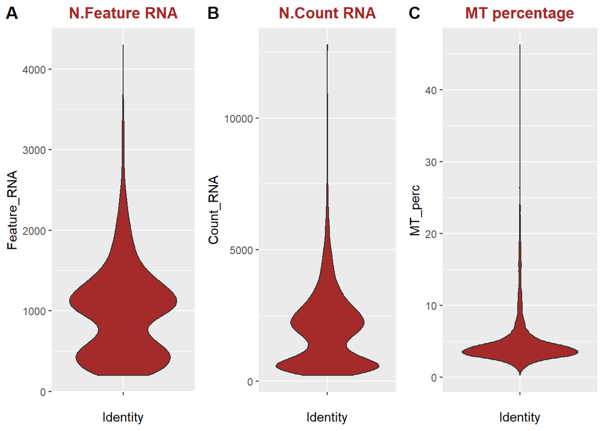

```r
#### Add percentage of mithocondria
brain[["percent.mt"]] <- PercentageFeatureSet(brain, pattern = "^mt-")


brain_df <- data.frame(brain@meta.data[["nCount_RNA"]], brain@meta.data[["nFeature_RNA"]], brain@meta.data[["percent.mt"]])
colnames(brain_df) <- c("Count_RNA", "Feature_RNA", "MT_perc")

## Plots
feature <- ggplot(brain_df) + geom_violin(aes(x = "", y = Feature_RNA), fill = "brown") +
  ggtitle("N.Feature RNA") + xlab("Identity") +
  theme(plot.title = element_text(hjust = 0.5, face = "bold", colour = "brown"))

count <- ggplot(brain_df) + geom_violin(aes(x = "", y = Count_RNA), fill = "brown") +
  ggtitle("N.Count RNA") + xlab("Identity") +
  theme(plot.title = element_text(hjust = 0.5, face = "bold", colour = "brown"))

mt <- ggplot(brain_df) + geom_violin(aes(x = "", y = MT_perc), fill = "brown") +
  ggtitle("MT percentage") + xlab("Identity") +
  theme(plot.title = element_text(hjust = 0.5, face = "bold", colour = "brown"))

ggarrange(feature, count, mt,
          labels = c("A", "B", "C"),
          ncol = 3, nrow = 1)
```

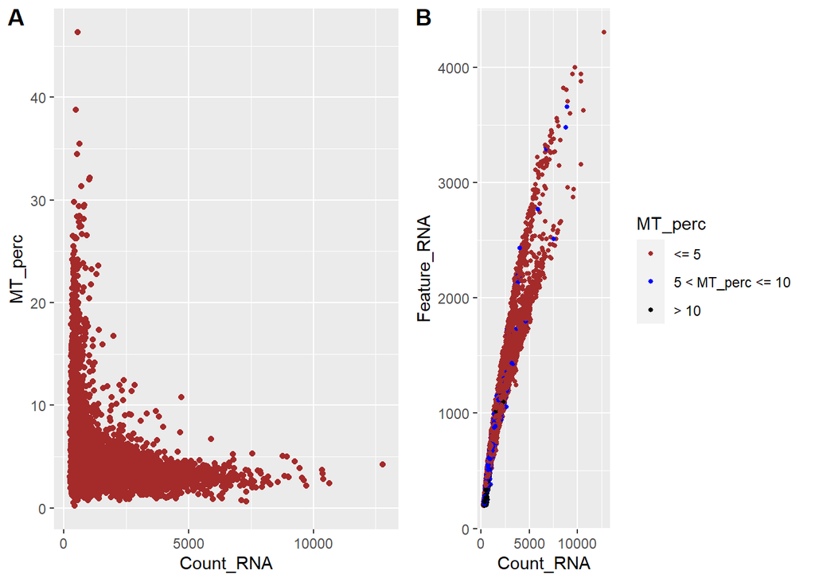

```r
p1 <- ggplot(brain_df) + geom_point(aes(x = Count_RNA, y = MT_perc), col = "brown")
p2 <- ggplot(brain_df, aes(x = Count_RNA, y = Feature_RNA)) + geom_point(aes(colour = cut(MT_perc, c(-Inf, 5, 10, Inf))),
                                                                        size = 1) +
  scale_color_manual(name = "MT_perc",
                     values = c("(-Inf,5]" = "brown",
                                "(5,10]" = "blue",
                                "(10, Inf]" = "black"),
                     labels = c("<= 5", "5 < MT_perc <= 10", "> 10"))

ggarrange(p1, p2,
          labels = c("A", "B"),
          ncol = 2, nrow = 1)
```

## Filtering

The filtering that is done in the vignette uses as parameters the number of expressed genes, that should be greater the 200 and smaller than 2500 and the percentage of mitochondrial RNA which should be smaller than 5%. However, those data seems to be not particularly good in term of quality. To do a good filtering we have to change the parameters with respect to those reported in the vignette. We will start considering the information that we got from previous studies: in PanglaoDB we have already said that they counted only the cells with a value of count RNA which is higher than 1000. Also, from the paper we can read that they have considered invalid cells with a number of UMIs (count RNA) smaller than 600. For my analysis I have decided to use as threshold value 1000 as in PanglaoDB, the reason for that is that it seems to work better for the analysis, moreover the value of 600 indicated in the paper is used only for the first step in their pipeline, in fact during the whole pipeline they perform selection of cells in many different steps based on others criteria, so it seems reasonable to use a value that is higher than the one they provided. According to this parameter I have decided to use the same values of the vignette for what regards the number of expressed genes. Finally, since the average percentage of mitochondrial RNA is high the threshold of 10% may work be better than the one proposed in the vignette. So, to recapitulate the parameters that I have used are: expressed genes > 200 and < 2500, RNA count > 1000 and MT percentage < 10%. Proceeding with those results seems to give a good result in terms of number of clusters, but especially a valid explanation of the markers that are present in each cluster. After performing the filtering, the number of cells that is retained is like the one that is indicated by PanglaoDB, that’s because we have used almost the same filtering. The cells that we will use in the downstream analysis are 4441.

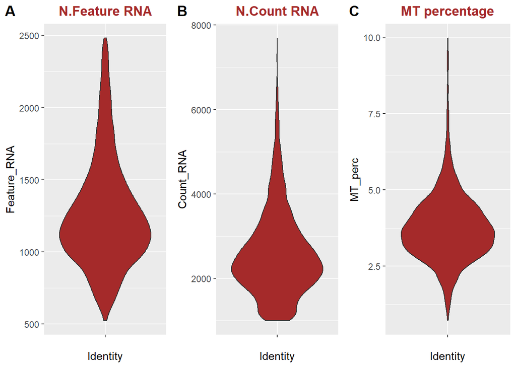

```r
brain_sub <- subset(brain, subset = nFeature_RNA > 200 & nFeature_RNA < 2500 & percent.mt < 10 & nCount_RNA > 1000)
brain_df_sub <- data.frame(brain_sub@meta.data[["nCount_RNA"]], brain_sub@meta.data[["nFeature_RNA"]], brain_sub@meta.data[["percent.mt"]])
colnames(brain_df_sub) <- c("Count_RNA", "Feature_RNA", "MT_perc")

## Plots
feature_s <- ggplot(brain_df_sub) + geom_violin(aes(x = "", y = Feature_RNA), fill = "brown") +
  ggtitle("N.Feature RNA") + xlab("Identity") +
  theme(plot.title = element_text(hjust = 0.5, face = "bold", colour = "brown"))

count_s <- ggplot(brain_df_sub) + geom_violin(aes(x = "", y = Count_RNA), fill = "brown") +
  ggtitle("N.Count RNA") + xlab("Identity") +
  theme(plot.title = element_text(hjust = 0.5, face = "bold", colour = "brown"))

mt_s <- ggplot(brain_df_sub) + geom_violin(aes(x = "", y = MT_perc), fill = "brown") +
  ggtitle("MT percentage") + xlab("Identity") +
  theme(plot.title = element_text(hjust = 0.5, face = "bold", colour = "brown"))

ggarrange(feature_s, count_s, mt_s,
          labels = c("A", "B", "C"),
          ncol = 3, nrow = 1)
```

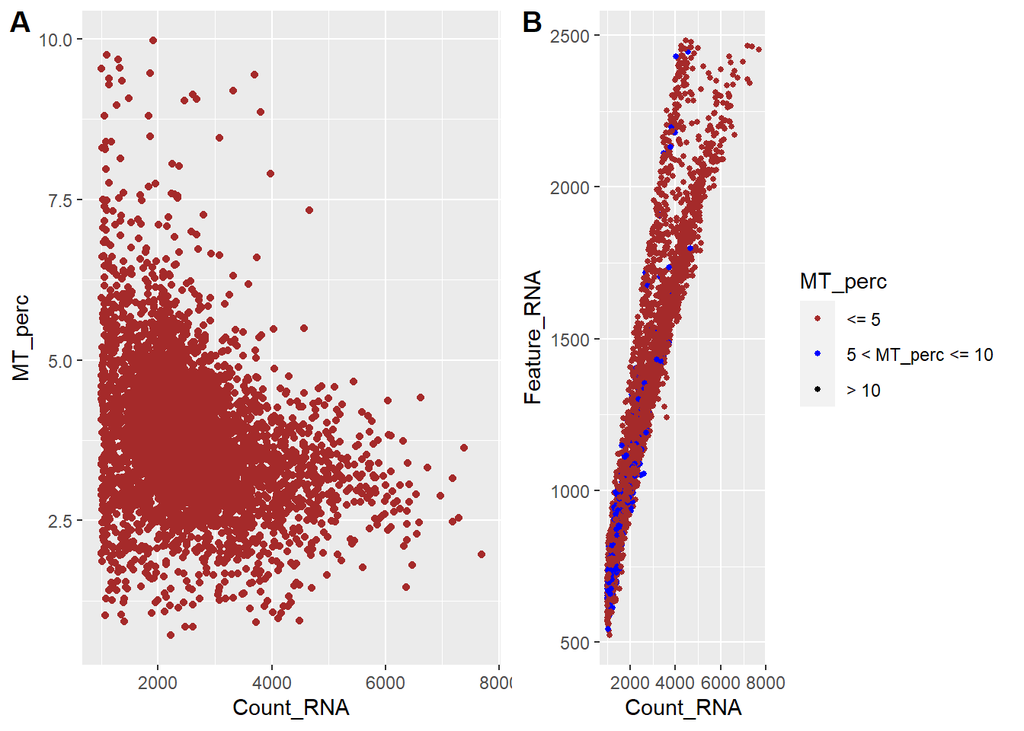

```r
p1_s <- ggplot(brain_df_sub) + geom_point(aes(x = Count_RNA, y = MT_perc), col = "brown")
p2_s <- ggplot(brain_df_sub, aes(x = Count_RNA, y = Feature_RNA)) + geom_point(aes(colour = cut(MT_perc, c(-Inf, 5, 10, Inf))),
                                                                        size = 1) +
  scale_color_manual(name = "MT_perc",
                     values = c("(-Inf,5]" = "brown",
                                "(5,10]" = "blue",
                                "(10, Inf]" = "black"),
                     labels = c("<= 5", "5 < MT_perc <= 10", "> 10"))

ggarrange(p1_s, p2_s,
          labels = c("A", "B"),
          ncol = 2, nrow = 1)
```

```r
brain
```

```
## An object of class Seurat
## 21185 features across 6848 samples within 1 assay
## Active assay: RNA (21185 features, 0 variable features)
```

```r
brain_sub
```

```
## An object of class Seurat
## 21185 features across 4441 samples within 1 assay
## Active assay: RNA (21185 features, 0 variable features)
```

## Normalization

Before selecting the most variable genes we have to normalize the data, after the filtering. The normalization is performed using the Seurat package and its default method, that is we normalize the gene counts for each cell by the total counts for each cell, multiplies this by a scale factor (10000 by default), and log-transforms the result. Now that we have performed normalization, we can select the genes that are more variable across our dataset. The reason for which we want to do this is that housekeeping genes, that are similarly expressed in all cell populations, are not useful for the purpose of identifying populations of cells in the dataset. Thus, it is often useful to select a subset of genes that display higher than average variability among cells to be used for dimensionality reduction and clustering of cells.

```r
brain <- NormalizeData(brain_sub, normalization.method = "LogNormalize", scale.factor = 10000)
```

## Most variable genes

We can see from the plot that below the 10 genes which are more variable. There are others which have a standardized variance that is quite high. We may also want to look at the expression of the top genes which have the higher standardized variance, for example we can have a plot for each of them where each point represents a cell and the expression of the specific gene in the cell. In the image we can see how variable is the expression of the genes and we can also appreciate the normalization on the expression levels.

[1] “Cst3” “Meg3” “Bsg” “Rgs5” “Ctss” “Apoe” “hexb” “Acta2” “Gfap” [10] “C1qa”

```
## When using repel, set xnudge and ynudge to 0 for optimal results
```

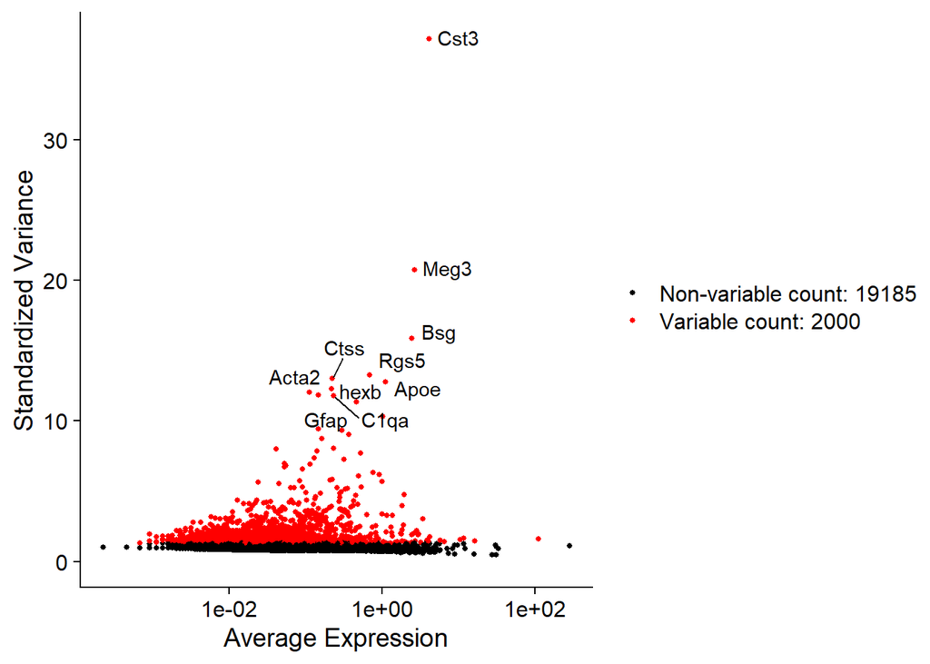

```r
plot1 <- VariableFeaturePlot(brain)
LabelPoints(plot = plot1, points = top10, repel = TRUE)
```

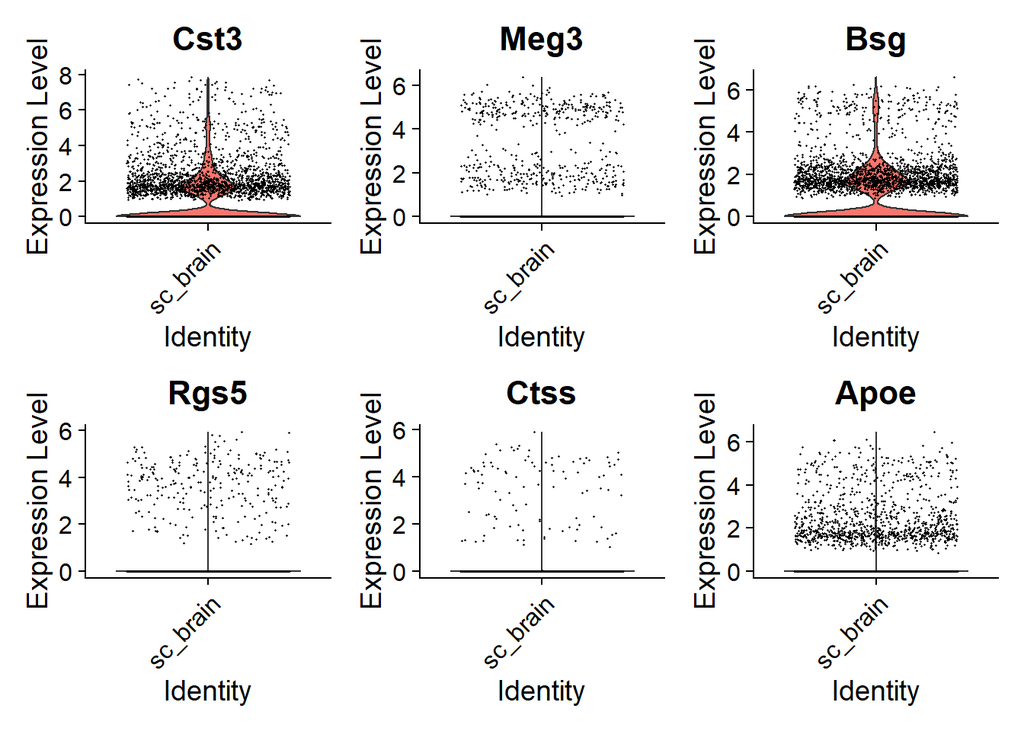

```r
VlnPlot(brain, features = head(VariableFeatures(object = brain), 6), ncol = 3, pt.size = 0.2)
```

## Cell cycle

If we want to check the effect of the cell cycle phase, we have to apply Principal Component Analysis (PCA), to do that however, we need to scale our data after having normalized them. This is because when we apply this kind of algorithm, we want all our genes to have mean expression of 0 and variance of 1 otherwise the absolute value of expression will influence the results of PCA, specifically gene with a higher mean expression will have a higher weight with respect to the other. After having performed the scaling, we retrieve from Seurat the list of genes that are specific for the g2m and s phase of the cell cycle. Those lists of genes are specific for genes of Homo sapiens, but since the name of the gene in Mus Musculus is very similar, we just need to change the name of the genes lo lower case to find the list of genes of our interest, except for the first letter. After this small adjustment we can run the PCA and plot the 2 principal components to see whether cells in the same phase of the cell cycle cluster together and if, eventually, we need to regress out the cell cycle from the analysis. From the plot we see that they do not cluster together so we can proceed with the analysis. We can also see 2 other types of plot: in the first one we can see the expression of some genes in terms of the principal components that we have just computed while in the second one we can see heatmaps, here we can see expression of the most variable genes. We can notice how going on with the principal components there is always less information since the difference in variability of these genes is more difficult to observe.

```r
s.genes <- str_to_title(cc.genes$s.genes)
g2m.genes <- str_to_title(cc.genes$g2m.genes)

## Scaling
all.genes <- rownames(brain)
brain <- ScaleData(brain, features = all.genes)
brain <- CellCycleScoring(brain, s.features = s.genes, g2m.features = g2m.genes, set.ident = TRUE)
brain <- RunPCA(brain, features = VariableFeatures(object = brain))
```

```
## PC_ 1
## Positive:  Meg3, Snhg11, Sncb, Celf4, Snap25, Ly6h, Syp, Ndrg4, Nsg2, Disp2
##     Tmem130, Gap43, Stmn2, Chd3os, Nrsn2, Slc12a5, Resp18, Ctxn2, Stmn3, Gng3
##     Syt4, Bex2, Thy1, Gpm6a, Syt1, Nrsn1, Rtn1, Gabra1, Gnas, Scg2
## Negative:  Cldn11, Fth1, Mal, Mobp, Trf, Tspan2, Etv1, Dbi, Arpc1a, Opalin
##     Apod, Grb14, Klf13, Ptgds, Cpox, Cd81, Hmgcs1, Hapln2, Gng12, Sirt2
##     Adamts4, Serinc5, Clic4, Sema4d, Ddr1, Marcksl1, Arpc1b, Cd9, Nfasc, Hist1h1c
## PC_ 2
## Positive:  Cldn11, Tspan2, Mobp, Mal, Trf, Hmgcs1, Nap1l5, Ank3, Fth1, Snrpn
##     Pcsk1n, Arpc1a, Opalin, Marcksl1, Etv1, Cpox, Pfn2, Nfasc, Grb14, Apod
##     Fabp5, Snhg11, Sncb, Scg5, Ptgds, Snap25, RP23-81C12.1, Ahi1, Chd3os, Syp
## Negative:  Cldn5, Flt1, Ly6c1, Rgs5, Igfbp7, Itm2a, Egfl7, Ly6a, Id1, Klf2
##     Ptprb, Adgrf5, Slco1a4, Ifitm3, Ly6e, Slco1c1, Cd34, Abcb1a, Id3, Podxl
##     Col4a1, Car4, Pecam1, Cd93, Eng, Kank3, Adgrl4, Ablim1, Crip2, Fn1
## PC_ 3
## Positive:  C1qa, C1qb, C1qc, Ctss, Tyrobp, Fcer1g, Trem2, P2ry12, Aif1, Csf1r
##     hexb, Selplg, Ly86, Gpr34, Laptm5, Tmem119, Fcrls, Cx3cr1, Fcgr3, Pld4
##     Cd53, Cd68, Ctsc, Fcgr1, Spi1, Rgs10, Alox5ap, Cd300d, Rnase4, Siglech
## Negative:  Cldn11, Mal, Tspan2, Flt1, Rgs5, Klf13, Ly6c1, Dynll1, Cldn5, Ptprb
##     Mobp, Slc6a6, Ly6a, Itm2a, Adgrf5, Slco1a4, Igfbp7, Arpc1a, Ebf1, Abcb1a
##     Podxl, Higd1b, Egfl7, Clic4, Pecam1, Spock2, Ank3, Ablim1, Cd93, Sox17
## PC_ 4
## Positive:  Trf, Mal, Fth1, Calm2, Ctss, C1qc, C1qb, Cldn11, C1qa, Tyrobp
##     Trem2, P2ry12, Aif1, Rgs10, Selplg, Fcer1g, Etv1, Mobp, Csf1r, Tmem119
##     Pld4, Cx3cr1, Gpr34, Tspan2, Ly86, Fcrls, Apod, Fcgr3, Laptm5, hexb
## Negative:  Gja1, Aqp4, Slc4a4, Slc6a11, Gpr37l1, Clu, Fgfr3, Atp1b2, Ntsr2, RP23-168E14.7
##     Slc1a2, Agt, Pla2g7, Aldoc, Mlc1, Sparcl1, Ptprz1, Bcan, Acsbg1, Serpine2
##     Itih3, Atp1a2, Plpp3, Tril, Cxcl14, Ntrk2, Ednrb, Tmem47, Ncan, Cldn10
## PC_ 5
## Positive:  Gpr17, RP23-47H16.3, RP23-95H5.1, Fyn, Slc1a1, Col9a3, Marcks, Frmd4a, Kank1, Opcml
##     Tcf7l2, Mycl, Rassf10, Bmp4, AC163993.2, Rras2, Neu4, Pak4, Mpzl1, RP23-361B11.2
##     Tmem163, Cnksr3, Vcan, Rnf122, Nfasc, RP23-416H10.8, Rasgef1b, Dynll2, Sirt2, Trio
## Negative:  Fth1, Mal, Trf, Etv1, Apod, Sparcl1, Hapln2, Gja1, Aqp4, Ndrg2
##     Apoe, Mlc1, Slc4a4, Chchd10, Clu, Atp1b2, Slc1a2, Slc6a11, Mt3, Ntsr2
##     Fgfr3, Tmem47, Agt, Pla2g7, Itih3, Dbi, Sdc4, Acsbg1, Fxyd1, Cpe
```

```r
print(brain[["pca"]], dims = 1:5, nfeatures = 5)
```

```
## PC_ 1
## Positive:  Meg3, Snhg11, Sncb, Celf4, Snap25
## Negative:  Cldn11, Fth1, Mal, Mobp, Trf
## PC_ 2
## Positive:  Cldn11, Tspan2, Mobp, Mal, Trf
## Negative:  Cldn5, Flt1, Ly6c1, Rgs5, Igfbp7
## PC_ 3
## Positive:  C1qa, C1qb, C1qc, Ctss, Tyrobp
## Negative:  Cldn11, Mal, Tspan2, Flt1, Rgs5
## PC_ 4
## Positive:  Trf, Mal, Fth1, Calm2, Ctss
## Negative:  Gja1, Aqp4, Slc4a4, Slc6a11, Gpr37l1
## PC_ 5
## Positive:  Gpr17, RP23-47H16.3, RP23-95H5.1, Fyn, Slc1a1
## Negative:  Fth1, Mal, Trf, Etv1, Apod
```

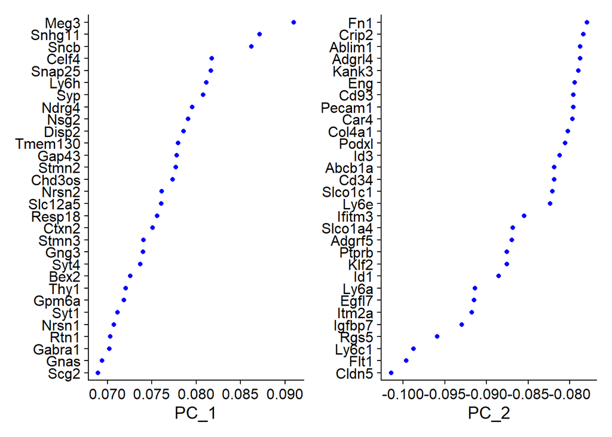

```r
VizDimLoadings(brain, dims = 1:2, reduction = "pca")
```

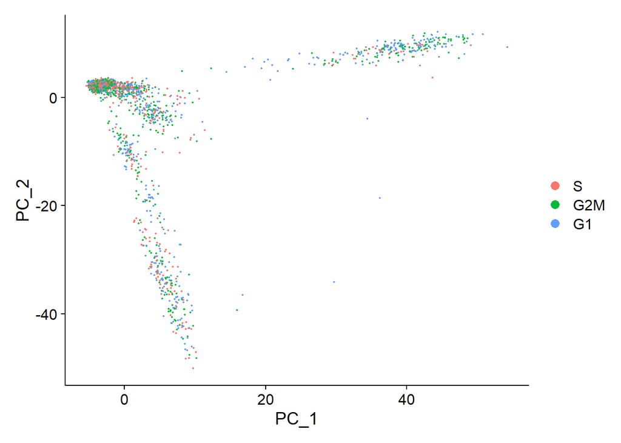

```r
DimPlot(brain, reduction = "pca")
```

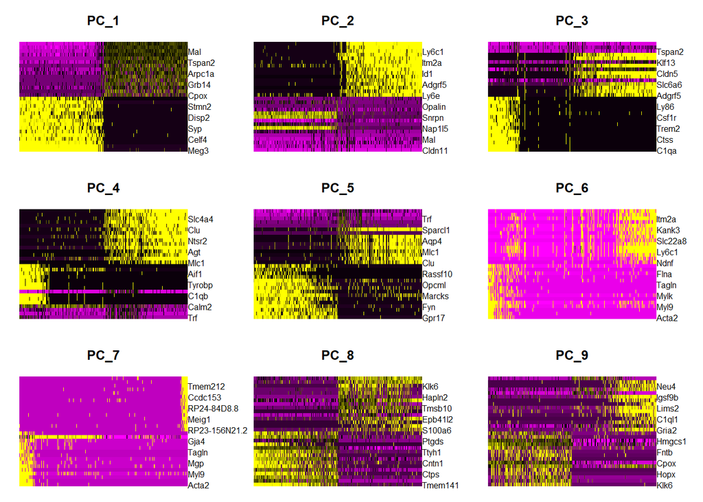

```r
DimHeatmap(brain, dims = 1:9, cells = 500, balanced = TRUE)
```

## Elbow plot

The elbow plot is used to decide how many principal components we want to use for the clustering. The plot is monotonically decreasing since as definition every principal component will explain less variance with respect to the ones preceding it. The idea of this plot is to try to assess through a visual inspection which is the ideal number of principal components, to do that we have to look for an elbow in the plot, in our case we can say that the elbow is around the 10th PC, however, sometimes may be useful to retain some principal components more than the one find looking at the elbow plot. A very similar plot, which I prefer, is the one which clearly express the percentage of variance that is explained by each PC. Obviously, the shape of the plot is exactly the same, but we can appreciate how much we will lose in terms of variance if we keep out some principal components.

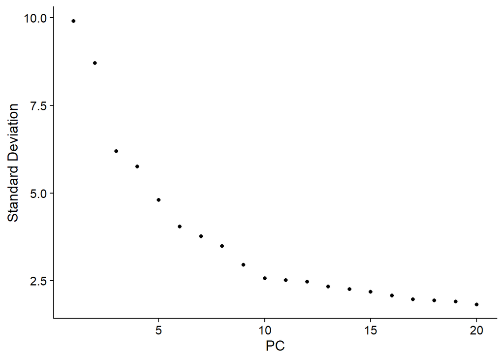

```r
ElbowPlot(brain, ndims = 20)
```

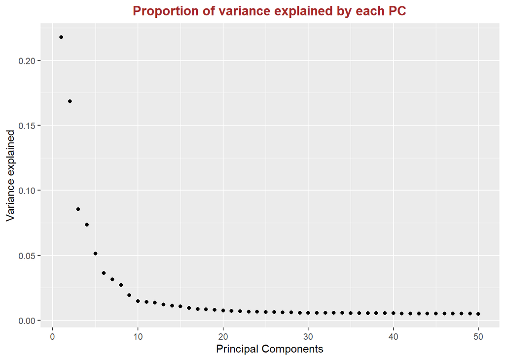

```r
sd2 <- brain@reductions[["pca"]]@stdev**2
var_exp <- as.data.frame(sd2/sum(sd2))
var_exp$cum <- cumsum(var_exp$`sd2/sum(sd2)`)
var_exp$PC <- seq(1,50)
ggplot(var_exp) + geom_point(aes(x = PC, y = sd2/sum(sd2))) + xlab("Principal Components") + ylab("Variance explained") +
  ggtitle("Proportion of variance explained by each PC") +
  theme(plot.title = element_text(hjust = 0.5, face = "bold", colour = "brown"))
```

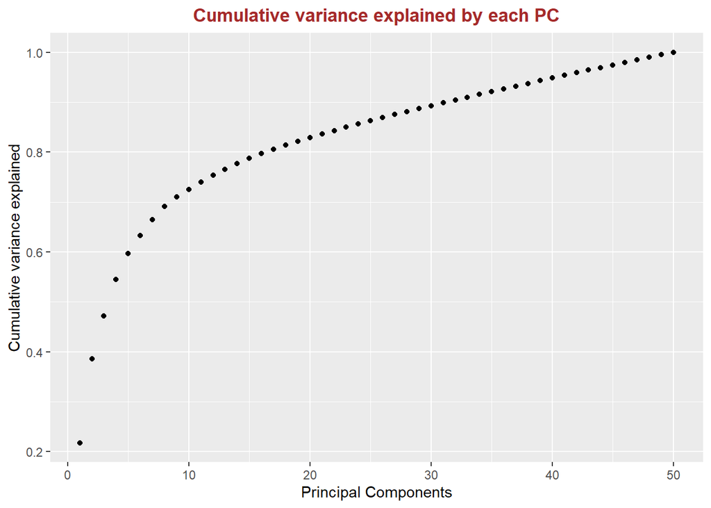

```r
ggplot(var_exp) + geom_point(aes(x = PC, y = cum)) + xlab("Principal Components") + ylab("Cumulative variance explained") +
  ggtitle("Cumulative variance explained by each PC") +
  theme(plot.title = element_text(hjust = 0.5, face = "bold", colour = "brown"))
```

## Clustering

Once we have decided the number of principal components that we want to use we want to be able to cluster the cells according to the cell type. In order to do that we need a clustering algorithm, we will use the default one used by Seurat, through the FindNeighbors and FindClusters built-in functions, which is a graph-based method. To be more precise the method used is called Louvain multilevel community clustering and the idea is to try to find clusters optimizing the modularity. This kind of method is also mentioned in the paper; however, they point out the fact that with this technique it is very difficult to identify small clusters, this problem is due to the fact that, when we have many cells (500000 in the paper), it is not possible to have values of resolution able to identify such small clusters. The resolution indeed, is the only parameter of the algorithm that can be tuned and acts on the granularity of the clusters, where a bigger resolution will tend to find more clusters with respect to a lower one. Since this is the only parameter that we can modify this also mean that we cannot choose a priori the number of clusters. To avoid this problem related to small clusters in the paper they suggest using different techniques: the one that they find to be useful in this case is first use the common Louvain method to find the clusters and then in a second step run a density-based algorithm such as DBSCAN on every cluster found with the first step. For what concern our dataset we do not have a big number of cells since it is in the order of few thousands so we can use the Louvain method without having problems in finding small clusters. The values suggested for the resolution with the number of cells that we have is between 0.4 and 1.2. In detail, with Seurat, we build a KNN graph using Euclidean distances in the lower dimensional space that we have obtained before with PCA and then we try to find the clusters according to a loss function which is the modularity. The parameters that we can modify are the resolution, mentioned before, and the number of principal components used to build the graph. Here we will first see the results of this procedure using the default parameters proposed in the vignette. We have 10 as number of principal components and 0.5 as resolution. However, we are going to see different dimensionality reduction techniques other than the PCA; the fact is that PCA is not suited for this particular job: the other two techniques are non-linear dimensionality methods and they are specifically designed for data visualization in a 2 dimensional space. The most common non-linear methods are Uniform Approximation and Projection method (UMAP) and t-distributed stochastic neighbor embedding (tSNE). The results obtained with each method can be seen in the plots below.

```r
#vignette parameters
pc_10_0.5 <- FindNeighbors(brain, dims = 1:10)
pc_10_0.5 <- FindClusters(pc_10_0.5, resolution = 0.5)
```

```
## Modularity Optimizer version 1.3.0 by Ludo Waltman and Nees Jan van Eck
##
## Number of nodes: 4441
## Number of edges: 146853
##
## Running Louvain algorithm...
## Maximum modularity in 10 random starts: 0.8831
## Number of communities: 13
## Elapsed time: 0 seconds
```

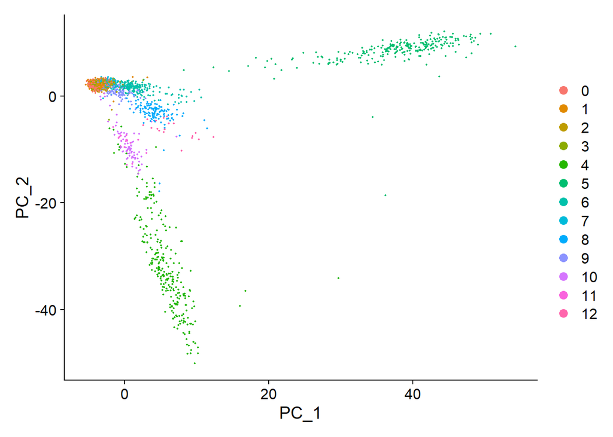

```r
DimPlot(pc_10_0.5, reduction = "pca")
```

```r
pc_10_0.5 <- RunUMAP(pc_10_0.5, dims = 1:10)
```

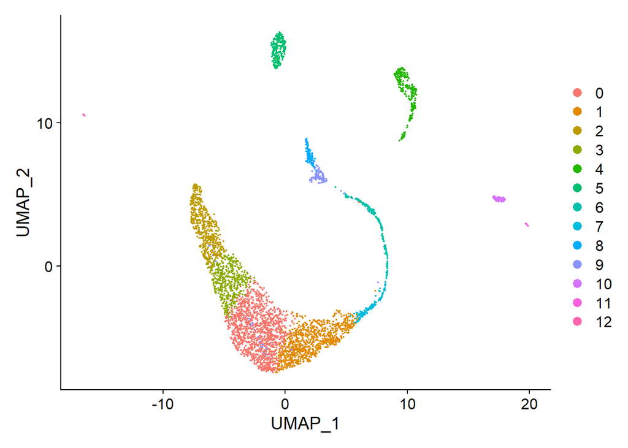

```r
DimPlot(pc_10_0.5, reduction = "umap")
```

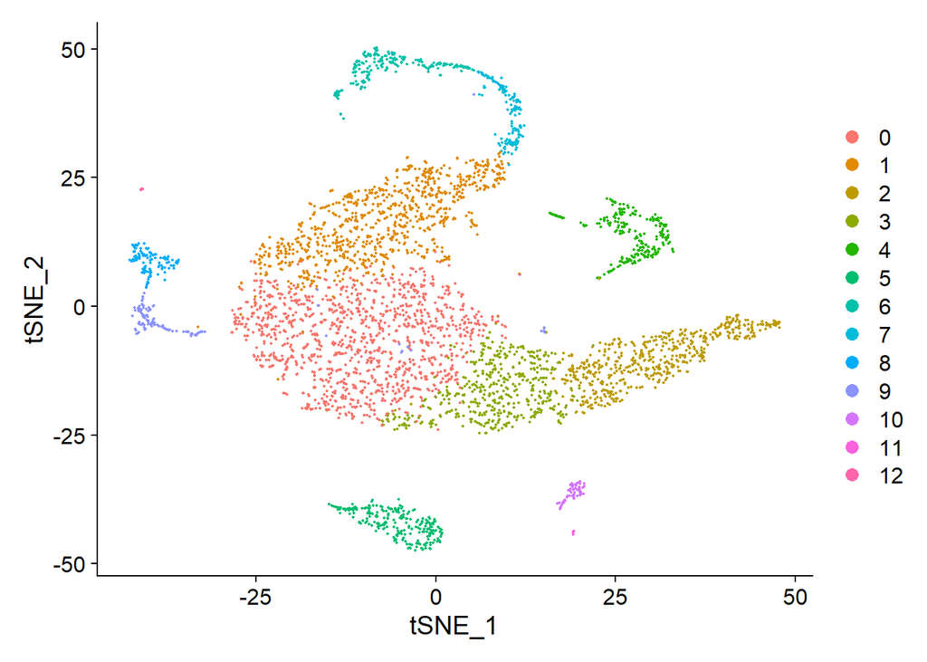

```r
pc_10_0.5 <- RunTSNE(pc_10_0.5, dims = 1:10)
DimPlot(pc_10_0.5, reduction = "tsne")
```

```r
table <- as.data.frame(table(pc_10_0.5$seurat_clusters))
table <- rbind(levels(table$Var1), table$Freq)
row.names(table) <- c("Cluster", "N. of Cells")
table <- as.data.frame(table)
```

|  | V1 | V2 | V3 | V4 | V5 | V6 | V7 | V8 | V9 | V10 | V11 | V12 | V13 |
| --- | --- | --- | --- | --- | --- | --- | --- | --- | --- | --- | --- | --- | --- |
| Cluster | 0 | 1 | 2 | 3 | 4 | 5 | 6 | 7 | 8 | 9 | 10 | 11 | 12 |
| N. of Cells | 1253 | 885 | 569 | 478 | 270 | 250 | 218 | 154 | 128 | 126 | 74 | 18 | 18 |

## Markers

```r
markers <- FindAllMarkers(object = pc_10_0.5, only.pos = TRUE, min.pct = 0.25, thresh.use = 0.25)
markers_df <- as.data.frame(markers %>% group_by(cluster) %>% top_n(n = 5, wt = avg_log2FC))

topmarkers <- as.data.frame(markers_df %>% group_by(cluster) %>% top_n(n = 1, wt = -p_val_adj)) %>%
    group_by(cluster) %>% top_n(n = 1, wt = avg_log2FC)


best_markers <- topmarkers$gene
```

| p_val | avg_log2FC | pct.1 | pct.2 | p_val_adj | cluster | gene |
| --- | --- | --- | --- | --- | --- | --- |
| 0 | 1.1457400 | 0.999 | 0.815 | 0 | 0 | Qdpr |
| 0 | 1.0834738 | 0.996 | 0.724 | 0 | 0 | Car2 |
| 0 | 1.0758203 | 0.981 | 0.763 | 0 | 0 | Glul |
| 0 | 0.9773634 | 0.761 | 0.414 | 0 | 0 | Ptgds |
| 0 | 0.8940671 | 0.716 | 0.447 | 0 | 0 | Hcn2 |
| 0 | 1.2590127 | 1.000 | 0.785 | 0 | 1 | Mal |

Here I give a label to each cluster according to the information found. Moreover we can see the UMAP previously plotted with the assigned labels.

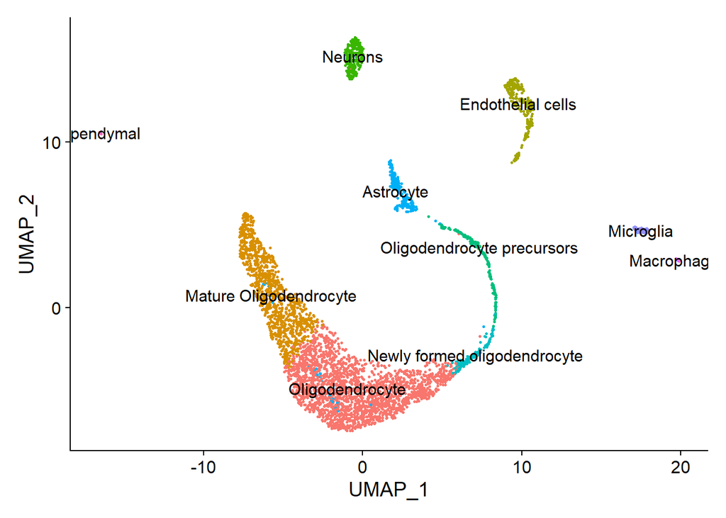

```r
clusters <- c("Oligodendrocyte", "Oligodendrocyte", "Mature Oligodendrocyte",
              "Mature Oligodendrocyte", "Endothelial cells", "Neurons",
              "Oligodendrocyte precursors", "Newly formed oligodendrocyte",
              "Astrocyte", "Astrocyte", "Microglia", "Macrophages", "Ependymal")

names(clusters) <- levels(pc_10_0.5)
pc_10_0.5 <- RenameIdents(pc_10_0.5, clusters)
DimPlot(pc_10_0.5, reduction = "umap", label = TRUE, pt.size = 0.5) + NoLegend()
```

## Plots for expression of markers

We can have 3 different types of plots. The first one is a dot-plot where we can see overall the expression of the top markers of each cluster. Ideally, we would like to have a clear diagonal, this would mean that the gene that we consider marker for a specific cluster is expressed only there and not also in other clusters. From the dot-plot obtained by this analysis we can see that we have a high average expression on the diagonal, however we can also see some dots that are outside, mainly they are present for the clusters referring to oligodendrocytes. Given the fact that we have many clusters closely related to the same cell type the markers are not completely specific, but we can see that the higher level of expression is present on the main diagonal. All those information can also be seen cluster-wise in the following image where we have two types of plots: the first one is the violin plot which is used to see the expression of the top marker for a specific cluster in all the clusters. The second plot is called feature plot and it is the overlap of the UMAP with the gene expression across the different cells. Basically, in this plot we will see an area of the UMAP colored with different shades of blue depending on the expression of the considered marker. Here for simplicity, only the plots referring to single cluster are present.

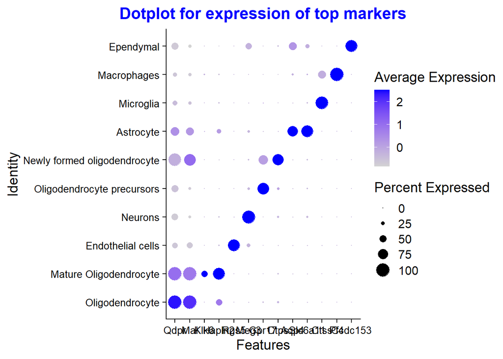

```r
DotPlot(pc_10_0.5, features = best_markers) + ggtitle("Dotplot for expression of top markers") +
  theme(plot.title = element_text(hjust = 0.5, face = "bold", colour = "blue"), axis.text = element_text(size = 10))
```

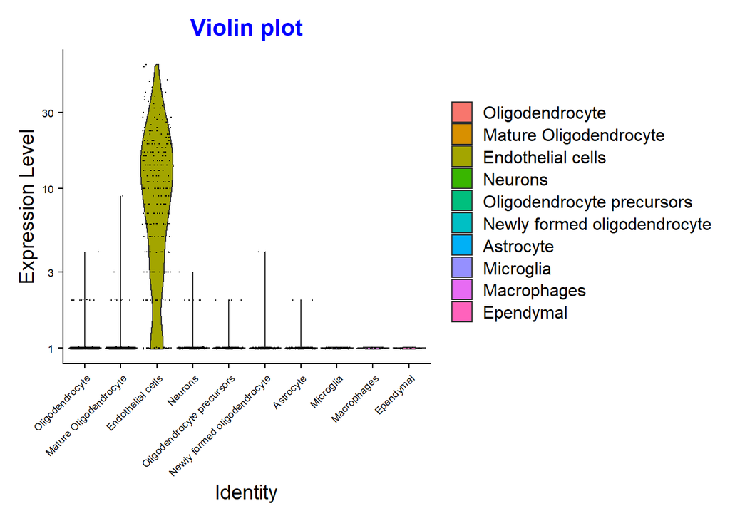

```r
VlnPlot(object = pc_10_0.5, features = best_markers[5], slot = "counts", log = TRUE) +
  ggtitle("Violin plot") +
  theme(plot.title = element_text(hjust = 0.5, face = "bold", colour = "blue"), axis.text = element_text(size = 7))
```

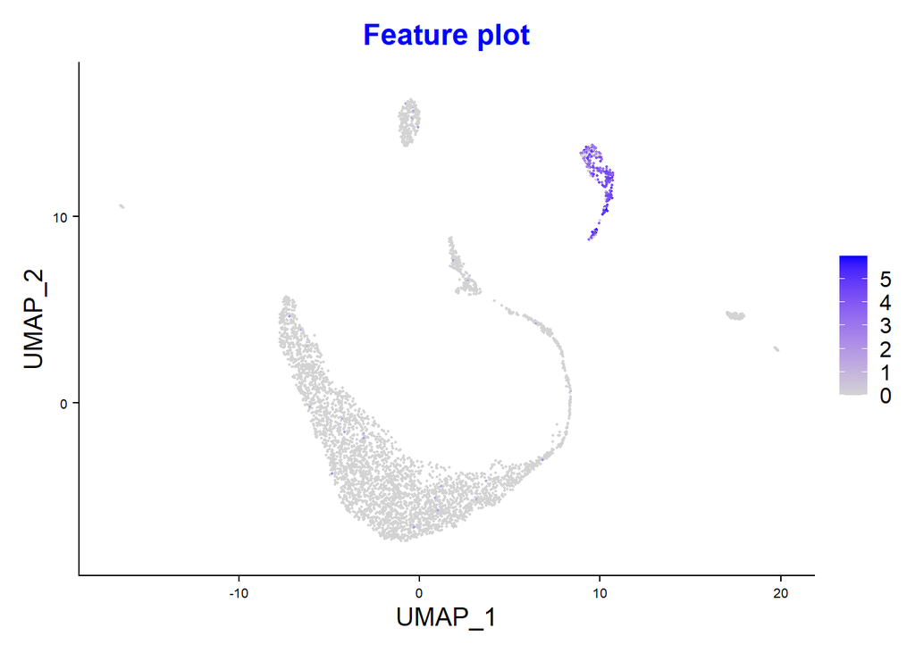

```r
FeaturePlot(pc_10_0.5, features = best_markers[5]) +
  ggtitle("Feature plot") +
  theme(plot.title = element_text(hjust = 0.5, face = "bold", colour = "blue"), axis.text = element_text(size = 7))
```